# Reproducible Research Class Assigement 1

Yuling Tu

September 12, 2017

# Reproducible Research Assignment 1

The variables included in this dataset are:

- steps: Number of steps taking in a 5-minute interval (missing values are coded as NA)
- date: The date on which the measurement was taken in YYYY-MM-DD format
- interval: Identifier for the 5-minute interval in which measurement was taken

The dataset is stored in a comma-separated-value (CSV) file and there are a total of 17,568 observations in this dataset.

Set up grobal setting echo=TRUE and root directory

# Loading and preprocessing the data

```r
if(!file.exists("repdata_data_activity.zip")) {
        temp <- tempfile()
        download.file("https://d396qusza40orc.cloudfront.net/repdata%2Fdata%2Factivity.zip",temp)
        unzip(temp)
        unlink(temp)
}

act <- read.csv(file = "activity.csv")
```

# Question 1: What is mean total number of steps taken per day?

For this part of the assignment, you can ignore the missing values in the dataset. xtable package is required Use “Inline text” to report mean and median

```r
dailysum <- aggregate(steps ~ date, act, sum, na.rm=TRUE)

library(xtable)
xtsum <- xtable(summary(dailysum))
print(xtsum, type="html")
```

```
## <!-- html table generated in R 3.3.1 by xtable 1.8-2 package -->
## <!-- Wed Sep 13 23:27:10 2017 -->
## <table border=1>
## <tr> <th>  </th> <th>         date </th> <th>     steps </th>  </tr>
##   <tr> <td align="right"> 1 </td> <td> 2012-10-02: 1   </td> <td> Min.   :   41   </td> </tr>
##   <tr> <td align="right"> 2 </td> <td> 2012-10-03: 1   </td> <td> 1st Qu.: 8841   </td> </tr>
##   <tr> <td align="right"> 3 </td> <td> 2012-10-04: 1   </td> <td> Median :10765   </td> </tr>
##   <tr> <td align="right"> 4 </td> <td> 2012-10-05: 1   </td> <td> Mean   :10766   </td> </tr>
##   <tr> <td align="right"> 5 </td> <td> 2012-10-06: 1   </td> <td> 3rd Qu.:13294   </td> </tr>
##   <tr> <td align="right"> 6 </td> <td> 2012-10-07: 1   </td> <td> Max.   :21194   </td> </tr>
##   <tr> <td align="right"> 7 </td> <td> (Other)   :47   </td> <td>  </td> </tr>
##    </table>
```

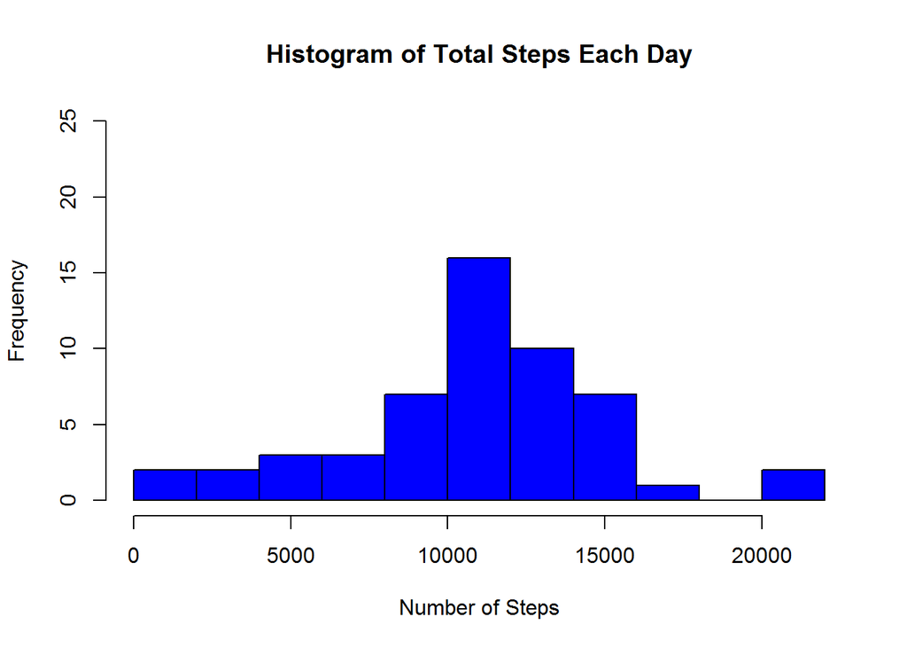

```r
hist(dailysum$steps,10, main = paste("Histogram of Total Steps Each Day"), col="blue", xlab="Number of Steps", ylim =c(0, 25))
```

```r
dailymean <- mean(dailysum$steps)
dailymedian <- median(dailysum$steps)
```

# Question 2: What is the average daily activity pattern?

Use summary table and plot to show the average steps for each interval Use “Inline Text” to report the max

```r
interval <- aggregate(steps ~ interval, act, mean, na.rm=TRUE)
xtint <- xtable(summary(interval))
print(xtint, type="html")
```

```
## <!-- html table generated in R 3.3.1 by xtable 1.8-2 package -->
## <!-- Wed Sep 13 23:27:10 2017 -->
## <table border=1>
## <tr> <th>  </th> <th>    interval </th> <th>     steps </th>  </tr>
##   <tr> <td align="right"> 1 </td> <td> Min.   :   0.0   </td> <td> Min.   :  0.000   </td> </tr>
##   <tr> <td align="right"> 2 </td> <td> 1st Qu.: 588.8   </td> <td> 1st Qu.:  2.486   </td> </tr>
##   <tr> <td align="right"> 3 </td> <td> Median :1177.5   </td> <td> Median : 34.113   </td> </tr>
##   <tr> <td align="right"> 4 </td> <td> Mean   :1177.5   </td> <td> Mean   : 37.383   </td> </tr>
##   <tr> <td align="right"> 5 </td> <td> 3rd Qu.:1766.2   </td> <td> 3rd Qu.: 52.835   </td> </tr>
##   <tr> <td align="right"> 6 </td> <td> Max.   :2355.0   </td> <td> Max.   :206.170   </td> </tr>
##    </table>
```

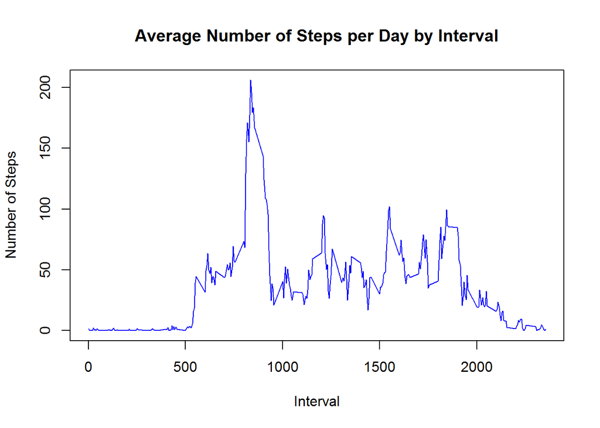

```r
plot(interval$interval,interval$steps, type="l", col="blue", xlab="Interval", ylab="Number of Steps",main="Average Number of Steps per Day by Interval")
```

```r
maxinterval <- interval[which.max(interval$steps),1]
```

** The maximum number of steps at 5-minute interval, on average across all the days in the dataset, contains the maximum number of steps, is 835.

# Question 3: Imputing missing values

Missing values were imputed by inserting the average for each interval by adding a new column (imputed_steps).  
Round the new column (imputed_steps)

```r
missing <- sum(is.na(act$steps))

act$imputed_steps <- ifelse(is.na(act$steps), round(interval$steps[match(act$interval, interval$interval)],0), act$steps)

imputed_sum <- aggregate(imputed_steps ~ date, act, sum)

library(xtable)
xtsum2 <- xtable(summary(imputed_sum))
print(xtsum2, type="html")
```

```
## <!-- html table generated in R 3.3.1 by xtable 1.8-2 package -->
## <!-- Wed Sep 13 23:27:10 2017 -->
## <table border=1>
## <tr> <th>  </th> <th>         date </th> <th> imputed_steps </th>  </tr>
##   <tr> <td align="right"> 1 </td> <td> 2012-10-01: 1   </td> <td> Min.   :   41   </td> </tr>
##   <tr> <td align="right"> 2 </td> <td> 2012-10-02: 1   </td> <td> 1st Qu.: 9819   </td> </tr>
##   <tr> <td align="right"> 3 </td> <td> 2012-10-03: 1   </td> <td> Median :10762   </td> </tr>
##   <tr> <td align="right"> 4 </td> <td> 2012-10-04: 1   </td> <td> Mean   :10766   </td> </tr>
##   <tr> <td align="right"> 5 </td> <td> 2012-10-05: 1   </td> <td> 3rd Qu.:12811   </td> </tr>
##   <tr> <td align="right"> 6 </td> <td> 2012-10-06: 1   </td> <td> Max.   :21194   </td> </tr>
##   <tr> <td align="right"> 7 </td> <td> (Other)   :55   </td> <td>  </td> </tr>
##    </table>
```

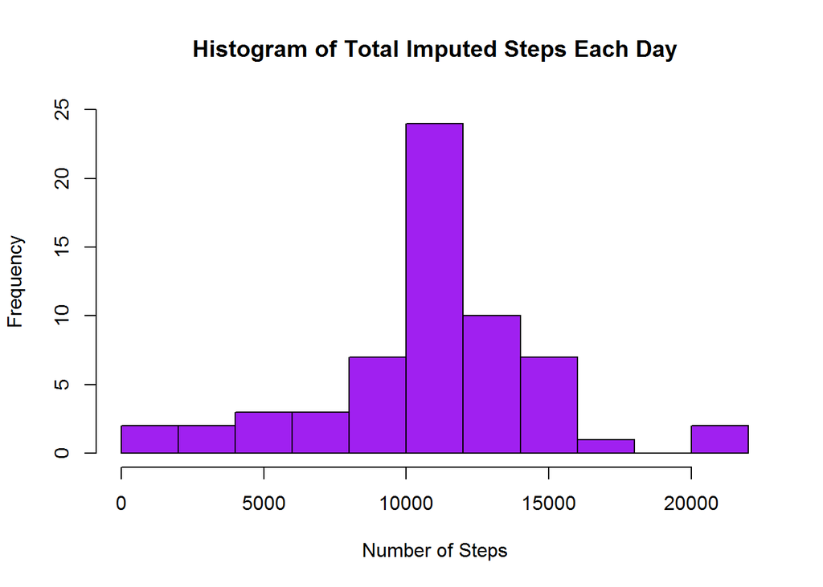

```r
hist(imputed_sum$imputed_steps,10, main = paste("Histogram of Total Imputed Steps Each Day"), col="purple", xlab="Number of Steps", ylim =c(0, 25))
```

```r
imputed_mean <- mean(imputed_sum$imputed_steps)
imputed_median <- median(imputed_sum$imputed_steps)

meandiff <- imputed_mean - dailymean
mediandiff <- imputed_median - dailymedian

totaldiff <- sum(act$imputed_steps) - sum(act$steps, na.rm = TRUE)
```

# Question 4: Are there differences in activity patterns between weekdays and weekends?

For this part the weekdays() function may be of some help here. Use the dataset with the filled-in missing values for this part.

```r
# date column is a factor type, need to convert to date type
act$datetype <- as.Date(act$date, format = "%Y-%m-%d")
# find a weekday for the datetype
act$weekday <- weekdays(act$datetype)
# define weekday type
act$daytype <- ifelse(act$weekday=='Saturday' | act$weekday=='Sunday', 'weekend','weekday')

imputed_weekday <- aggregate(imputed_steps ~ interval + daytype, act, mean)

library(lattice)
```

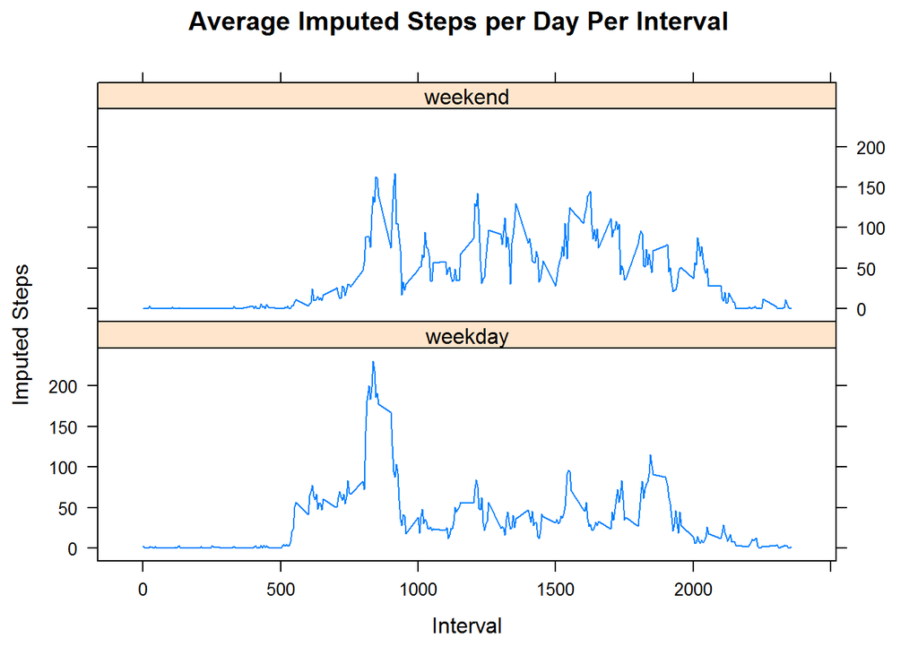

```r
xyplot(imputed_steps ~ interval|daytype,
       data= imputed_weekday,
       main="Average Imputed Steps per Day Per Interval",
       xlab="Interval",
       ylab="Imputed Steps",
       layout=c(1,2),
       type="l")
```

** From the panel charts, looks like those testers are more active earlier (before 800 interval) in the day during weekdays compared to weekends, but more active throughout the weekends compared with weekdays.